# Lab8

2026-04-24

# Link de GitHub:

https://github.com/SaintPage/Lab8_DM.git

```r
library(tidyverse)
library(tidymodels)
library(janitor)
library(lubridate)
library(stringr)
library(broom)
```

```r
tmp_env <- new.env()
load("listings.RData", envir = tmp_env)

objetos <- mget(ls(tmp_env), envir = tmp_env)

listings <- objetos %>%
  keep(~ is.data.frame(.x)) %>%
  .[[1]]

listings <- listings %>%
  slice_head(n = 1000)

dim(listings)
```

```
## [1] 1000   80
```

```r
glimpse(listings)
```

```
## Rows: 1,000
## Columns: 80
## $ id                                           <dbl> 5456, 6448, 8502, 13035, …
## $ listing_url                                  <chr> "https://www.airbnb.com/r…
## $ scrape_id                                    <dbl> 2.025092e+13, 2.025092e+1…
## $ last_scraped                                 <chr> "2025-09-17", "2025-09-17…
## $ source                                       <chr> "city scrape", "city scra…
## $ name                                         <chr> "Walk to 6th, Rainey St a…
## $ description                                  <chr> "Great central  location …
## $ neighborhood_overview                        <chr> "My neighborhood is ideal…
## $ picture_url                                  <chr> "https://a0.muscache.com/…
## $ host_id                                      <int> 8028, 14156, 25298, 50793…
## $ host_url                                     <chr> "https://www.airbnb.com/u…
## $ host_name                                    <chr> "Sylvia", "Amy", "Karen",…
## $ host_since                                   <chr> "2009-02-16", "2009-04-20…
```

[output cut: 67 more lines]

```r
parse_money_clean <- function(x) {
  if (is.numeric(x)) return(x)
  x %>%
    as.character() %>%
    str_replace_all("\\$", "") %>%
    str_replace_all(",", "") %>%
    str_trim() %>%
    na_if("") %>%
    as.numeric()
}

parse_percent_clean <- function(x) {
  if (is.numeric(x)) return(x)
  x %>%
    as.character() %>%
    str_replace_all("%", "") %>%
    str_trim() %>%
    na_if("") %>%
    as.numeric()
}

listings <- listings %>%
  clean_names()

if ("price" %in% names(listings)) {
  listings <- listings %>%
    mutate(price = parse_money_clean(price))
}


if ("host_response_rate" %in% names(listings)) {
  listings <- listings %>%
    mutate(host_response_rate = parse_percent_clean(host_response_rate))
}

if ("host_acceptance_rate" %in% names(listings)) {
  listings <- listings %>%
    mutate(host_acceptance_rate = parse_percent_clean(host_acceptance_rate))
}

cols_fecha <- c("host_since", "first_review", "last_review", "last_scraped")
cols_fecha <- cols_fecha[cols_fecha %in% names(listings)]

if (length(cols_fecha) > 0) {
  listings <- listings %>%
    mutate(across(all_of(cols_fecha), ~ suppressWarnings(ymd(.x))))
}

listings <- listings %>%
  select(where(~ !is.list(.x))) %>%
  mutate(across(where(is.character), as.factor))

summary(listings$price)
```

```
##    Min. 1st Qu.  Median    Mean 3rd Qu.    Max.
##    15.0    90.0   135.0   248.8   260.0  6500.0
```

# 3. Use como variable respuesta la variable categórica que especifica si la casa es barata, media o cara

```r
listings <- listings %>%
clean_names()

if ("price" %in% names(listings)) {
listings <- listings %>%
mutate(price = parse_money_clean(price)) %>%
mutate(
categoria_precio = case_when(
is.na(price)               ~ NA_character_,
price <= 119               ~ "Barata",
price > 119 & price <= 323 ~ "Media",
price > 323                ~ "Cara"
)
) %>%
mutate(
categoria_precio = factor(
categoria_precio,
levels = c("Barata", "Media", "Cara")
)
) %>%
filter(!is.na(categoria_precio))
}
```

# 1. Use los mismos conjuntos de entrenamiento y prueba de las hojas de trabajo pasadas para probar el algoritmo.

```r
set.seed(123)

split_master <- initial_split(
  listings,
  prop = 0.80,
  strata = categoria_precio
)

train_data <- training(split_master)
test_data  <- testing(split_master)

dim(train_data)
```

```
## [1] 798  81
```

```r
dim(test_data)
```

```
## [1] 202  81
```

```r
factor_cols <- names(train_data)[sapply(train_data, is.factor)]

for (col in factor_cols) {
  if (col %in% names(test_data)) {
    test_data[[col]] <- factor(test_data[[col]], levels = levels(train_data[[col]]))
  }
}
```

```r
vars_quitar <- intersect(
  names(train_data),
  c(
    "id", "listing_url", "scrape_id", "source", "name", "description",
    "neighborhood_overview", "picture_url", "host_id", "host_url",
    "host_name", "host_location", "host_about",
    "host_thumbnail_url", "host_picture_url",
    "license", "amenities"
  )
)

train_model <- train_data %>% select(-all_of(vars_quitar))
test_model  <- test_data  %>% select(-all_of(vars_quitar))
```

```r
vars_fuga <- intersect(
  names(train_model),
  c(
    "price",
    "estimated_revenue_l365d"
  )
)

train_model <- train_model %>% select(-all_of(vars_fuga))
test_model  <- test_model  %>% select(-all_of(vars_fuga))
```

# 2. Explore los datos y explique las transformaciones que debe hacerle para generar un modelo de máquinas vectoriales de soporte.

Para entrenar un modelo de máquinas vectoriales de soporte (SVM) con este conjunto de datos, primero es necesario definir la variable objetivo (por ejemplo, predecir price o clasificar room_type) y luego realizar una serie de transformaciones clave: eliminar columnas irrelevantes como identificadores, URLs y textos largos que no aportan al modelo; limpiar variables como price convirtiéndolas de texto a valores numéricos; tratar los valores faltantes eliminando columnas con demasiados nulos e imputando otros con medidas como la media o mediana; convertir variables categóricas (como property_type o host_is_superhost) en variables numéricas mediante codificación (one-hot encoding); transformar fechas en variables útiles (por ejemplo, años como anfitrión); convertir porcentajes a formato numérico; y finalmente escalar todas las variables numéricas (usando métodos como StandardScaler), ya que SVM es muy sensible a la escala, además de considerar el tratamiento de valores extremos para mejorar el rendimiento del modelo.

# 4. Genere varios (más de 2) modelos de SVM con diferentes kernels y distintos valores en los parámetros c, gamma (circular) y d (en caso de que utilice el polinomial). Puede tunear el modelo de forma automática siempre que explique los resultados

```r
library(tidymodels)
library(kernlab)
library(doParallel)

cl <- makePSOCKcluster(parallel::detectCores() - 1)
registerDoParallel(cl)

set.seed(123)
```

```r
vars_muy_nulas <- train_model %>%
  summarise(across(everything(), ~ mean(is.na(.)))) %>%
  pivot_longer(everything(), names_to = "variable", values_to = "prop_na") %>%
  filter(prop_na > 0.50, variable != "categoria_precio") %>%
  pull(variable)
```

```r
vars_alta_card <- train_model %>%
  select(where(is.factor)) %>%
  summarise(across(everything(), ~ n_distinct(.))) %>%
  pivot_longer(everything(), names_to = "variable", values_to = "n_lvls") %>%
  filter(n_lvls > 50) %>%
  pull(variable)

train_model <- train_model %>% select(-all_of(c(vars_muy_nulas, vars_alta_card)))
test_model  <- test_model  %>% select(-all_of(c(vars_muy_nulas, vars_alta_card)))
```

```r
folds_svm <- vfold_cv(train_model, v = 3, strata = categoria_precio)
```

```r
receta_svm <- recipe(categoria_precio ~ ., data = train_model) %>%
  step_date(all_date_predictors(), features = c("year", "month"),
            keep_original_cols = FALSE) %>%
  step_zv(all_predictors()) %>%
  step_impute_median(all_numeric_predictors()) %>%
  step_impute_mode(all_nominal_predictors()) %>%
  step_other(all_nominal_predictors(), threshold = 0.05) %>%
  step_dummy(all_nominal_predictors()) %>%
  step_nzv(all_predictors()) %>%
  step_normalize(all_numeric_predictors())

metricas_svm <- metric_set(accuracy, kap)
```

```r
svm_lineal <- svm_linear(mode = "classification", cost = tune()) %>%
  set_engine("kernlab")

svm_radial <- svm_rbf(mode = "classification",
                      cost = tune(), rbf_sigma = tune()) %>%
  set_engine("kernlab")

svm_poly <- svm_poly(mode = "classification",
                     cost = tune(), degree = tune()) %>%
  set_engine("kernlab")

wf_lineal <- workflow() %>% add_recipe(receta_svm) %>% add_model(svm_lineal)
wf_radial <- workflow() %>% add_recipe(receta_svm) %>% add_model(svm_radial)
wf_poly   <- workflow() %>% add_recipe(receta_svm) %>% add_model(svm_poly)
```

```r
# Grids reducidos pero cubriendo el espacio relevante
grid_lineal <- tibble(cost = c(0.1, 1, 10))

grid_radial <- crossing(
  cost      = c(0.1, 1, 10),
  rbf_sigma = c(0.01, 0.1)
)

grid_poly <- crossing(
  cost   = c(0.1, 1),
  degree = c(2, 3)
)
```

```r
ctrl <- control_grid(save_pred = FALSE, parallel_over = "everything")

set.seed(123)
res_lineal <- tune_grid(wf_lineal, resamples = folds_svm,
                        grid = grid_lineal, metrics = metricas_svm, control = ctrl)

res_radial <- tune_grid(wf_radial, resamples = folds_svm,
                        grid = grid_radial, metrics = metricas_svm, control = ctrl)
```

[output not shown]

```r
res_poly   <- tune_grid(wf_poly,   resamples = folds_svm,
                        grid = grid_poly,   metrics = metricas_svm, control = ctrl)
```

# 5. Use los modelos para predecir el valor de la variable respuesta

```r
mejores_cv <- bind_rows(
  show_best(res_lineal, metric = "accuracy", n = 1) %>% mutate(kernel = "Lineal"),
  show_best(res_radial, metric = "accuracy", n = 1) %>% mutate(kernel = "Radial"),
  show_best(res_poly,   metric = "accuracy", n = 1) %>% mutate(kernel = "Polinomial")
) %>% arrange(desc(mean))

mejores_cv
```

```
## # A tibble: 3 × 10
##    cost .metric  .estimator  mean     n std_err .config  kernel rbf_sigma degree
##   <dbl> <chr>    <chr>      <dbl> <int>   <dbl> <chr>    <chr>      <dbl>  <dbl>
## 1  10   accuracy multiclass 0.728     3 0.0152  pre0_mo… Radial      0.01     NA
## 2   0.1 accuracy multiclass 0.708     3 0.00383 pre0_mo… Lineal     NA        NA
## 3   0.1 accuracy multiclass 0.692     3 0.00816 pre0_mo… Polin…     NA         3
```

```r
best_lineal <- select_best(res_lineal, metric = "accuracy")
best_radial <- select_best(res_radial, metric = "accuracy")
best_poly   <- select_best(res_poly,   metric = "accuracy")
```

```r
evaluar_svm <- function(wf, best_params, nombre_kernel) {
  wf_final  <- finalize_workflow(wf, best_params)
  fit_final <- fit(wf_final, data = train_model)

  pred <- predict(fit_final, new_data = test_model) %>%
    bind_cols(test_model %>% select(categoria_precio))

  metricas <- metricas_svm(pred, truth = categoria_precio,
                           estimate = .pred_class) %>%
    mutate(kernel = nombre_kernel, .before = 1)

  matriz <- conf_mat(pred, truth = categoria_precio, estimate = .pred_class)

  list(modelo = fit_final, predicciones = pred,
       metricas = metricas, matriz_confusion = matriz)
}

final_lineal <- evaluar_svm(wf_lineal, best_lineal, "Lineal")
final_radial <- evaluar_svm(wf_radial, best_radial, "Radial")
final_poly   <- evaluar_svm(wf_poly,   best_poly,   "Polinomial")

resultados_test <- bind_rows(
  final_lineal$metricas, final_radial$metricas, final_poly$metricas
) %>% arrange(desc(.estimate))

resultados_test
```

```
## # A tibble: 6 × 4
##   kernel     .metric  .estimator .estimate
##   <chr>      <chr>    <chr>          <dbl>
## 1 Lineal     accuracy multiclass     0.693
## 2 Radial     accuracy multiclass     0.683
## 3 Polinomial accuracy multiclass     0.639
## 4 Lineal     kap      multiclass     0.512
## 5 Radial     kap      multiclass     0.497
## 6 Polinomial kap      multiclass     0.417
```

# 6.Haga las matrices de confusión respectivas.

```r
final_lineal$matriz_confusion
```

```
##           Truth
## Prediction Barata Media Cara
##     Barata     67    24    5
##     Media      15    49    9
##     Cara        2     7   24
```

```r
final_radial$matriz_confusion
```

```
##           Truth
## Prediction Barata Media Cara
##     Barata     64    25    2
##     Media      19    48   10
##     Cara        1     7   26
```

```r
final_poly$matriz_confusion
```

```
##           Truth
## Prediction Barata Media Cara
##     Barata     63    28    2
##     Media      21    47   17
##     Cara        0     5   19
```

# 7.Analice si los modelos están sobre ajustados o desajustados. ¿Qué puede hacer para manejar el sobreajuste o desajuste?.

```r
acc_train <- function(modelo_final, data_train) {
  predict(modelo_final$modelo, new_data = data_train) %>%
    bind_cols(data_train %>% select(categoria_precio)) %>%
    accuracy(truth = categoria_precio, estimate = .pred_class) %>%
    pull(.estimate)
}

train_lineal <- acc_train(final_lineal, train_model)
train_radial <- acc_train(final_radial, train_model)
train_poly   <- acc_train(final_poly,   train_model)

cv_lineal <- show_best(res_lineal, metric = "accuracy", n = 1)$mean
cv_radial <- show_best(res_radial, metric = "accuracy", n = 1)$mean
cv_poly   <- show_best(res_poly,   metric = "accuracy", n = 1)$mean

test_lineal <- final_lineal$metricas %>% filter(.metric == "accuracy") %>% pull(.estimate)
test_radial <- final_radial$metricas %>% filter(.metric == "accuracy") %>% pull(.estimate)
test_poly   <- final_poly$metricas   %>% filter(.metric == "accuracy") %>% pull(.estimate)

tabla_ajuste <- tibble(
  Kernel         = c("Lineal", "Radial", "Polinomial"),
  Acc_Train      = round(c(train_lineal, train_radial, train_poly), 4),
  Acc_CV         = round(c(cv_lineal,    cv_radial,    cv_poly),    4),
  Acc_Test       = round(c(test_lineal,  test_radial,  test_poly),  4),
  Gap_Train_Test = round(c(train_lineal - test_lineal,
                           train_radial - test_radial,
                           train_poly   - test_poly), 4)
) %>%
  mutate(
    Diagnostico = case_when(
      Acc_Train < 0.65              ~ "Subajuste",
      Gap_Train_Test > 0.10         ~ "Sobreajuste",
      abs(Acc_CV - Acc_Test) > 0.05 ~ "Sobreajuste leve",
      TRUE                          ~ "Buen ajuste"
    )
  )

print(tabla_ajuste)
```

```
## # A tibble: 3 × 6
##   Kernel     Acc_Train Acc_CV Acc_Test Gap_Train_Test Diagnostico
##   <chr>          <dbl>  <dbl>    <dbl>          <dbl> <chr>
## 1 Lineal         0.826  0.708    0.693          0.133 Sobreajuste
## 2 Radial         1      0.728    0.683          0.317 Sobreajuste
## 3 Polinomial     1      0.692    0.639          0.361 Sobreajuste
```

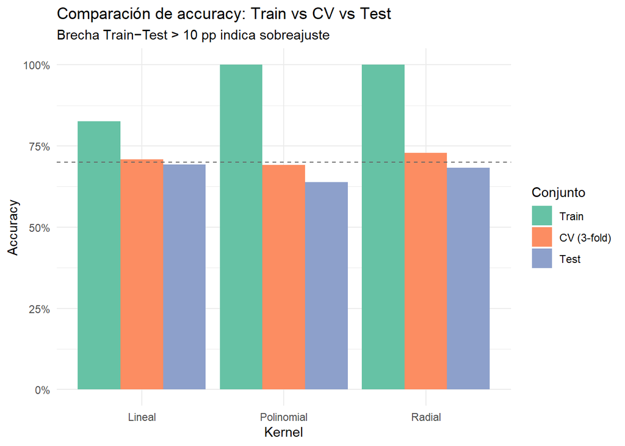

```r
tabla_ajuste %>%
  pivot_longer(cols = c(Acc_Train, Acc_CV, Acc_Test),
               names_to = "Conjunto", values_to = "Accuracy") %>%
  mutate(Conjunto = factor(Conjunto,
                           levels = c("Acc_Train", "Acc_CV", "Acc_Test"),
                           labels = c("Train", "CV (3-fold)", "Test"))) %>%
  ggplot(aes(x = Kernel, y = Accuracy, fill = Conjunto)) +
  geom_col(position = "dodge") +
  geom_hline(yintercept = 0.70, linetype = "dashed", color = "gray40") +
  scale_y_continuous(limits = c(0, 1), labels = scales::percent_format()) +
  scale_fill_brewer(palette = "Set2") +
  labs(title = "Comparación de accuracy: Train vs CV vs Test",
       subtitle = "Brecha Train−Test > 10 pp indica sobreajuste",
       x = "Kernel", y = "Accuracy", fill = "Conjunto") +
  theme_minimal()
```

```r
stopCluster(cl)
registerDoSEQ()
```

# 8. Compare los resultados obtenidos con los diferentes modelos que hizo en cuanto a efectividad, tiempo de procesamiento y equivocaciones (donde el algoritmo se equivocó más, donde se equivocó menos y la importancia que tienen los errores).

```r
medir_tiempo <- function(wf, best_params) {
  wf_final <- finalize_workflow(wf, best_params)
  t0 <- Sys.time()
  fit(wf_final, data = train_model)
  as.numeric(difftime(Sys.time(), t0, units = "secs"))
}

t_lineal <- medir_tiempo(wf_lineal, best_lineal)
t_radial <- medir_tiempo(wf_radial, best_radial)
t_poly   <- medir_tiempo(wf_poly,   best_poly)
```

```r
metricas_globales <- bind_rows(
  final_lineal$metricas,
  final_radial$metricas,
  final_poly$metricas
) %>%
  pivot_wider(names_from = .metric, values_from = .estimate) %>%
  select(kernel, accuracy, kap)
```

```r
metricas_por_clase <- function(fit_obj, nombre) {
  pred <- fit_obj$predicciones
  bind_rows(
    precision(pred, truth = categoria_precio, estimate = .pred_class,
              estimator = "macro"),
    recall(pred,    truth = categoria_precio, estimate = .pred_class,
           estimator = "macro"),
    f_meas(pred,    truth = categoria_precio, estimate = .pred_class,
           estimator = "macro")
  ) %>%
    select(.metric, .estimate) %>%
    pivot_wider(names_from = .metric, values_from = .estimate) %>%
    mutate(kernel = nombre, .before = 1)
}

por_clase <- bind_rows(
  metricas_por_clase(final_lineal, "Lineal"),
  metricas_por_clase(final_radial, "Radial"),
  metricas_por_clase(final_poly,   "Polinomial")
)
```

```r
tabla_comparativa <- metricas_globales %>%
  left_join(por_clase, by = "kernel") %>%
  mutate(tiempo_seg = round(c(t_lineal, t_radial, t_poly), 2)) %>%
  arrange(desc(accuracy))

tabla_comparativa
```

```
## # A tibble: 3 × 7
##   kernel     accuracy   kap precision recall f_meas tiempo_seg
##   <chr>         <dbl> <dbl>     <dbl>  <dbl>  <dbl>      <dbl>
## 1 Lineal        0.693 0.512     0.699  0.681  0.687       0.36
## 2 Radial        0.683 0.497     0.697  0.682  0.688       0.47
## 3 Polinomial    0.639 0.417     0.674  0.612  0.631       0.54
```

```r
errores_por_clase <- function(fit_obj, nombre) {
  cm <- as.matrix(fit_obj$matriz_confusion$table)
  total_real <- colSums(cm)        # cuántos hay realmente de cada clase
  aciertos   <- diag(cm)           # diagonal = aciertos
  errores    <- total_real - aciertos
  tibble(
    kernel = nombre,
    Clase  = colnames(cm),
    Total_Real = total_real,
    Errores    = errores,
    Tasa_Error = round(errores / total_real, 3)
  )
}

errores <- bind_rows(
  errores_por_clase(final_lineal, "Lineal"),
  errores_por_clase(final_radial, "Radial"),
  errores_por_clase(final_poly,   "Polinomial")
)

errores %>% arrange(kernel, desc(Tasa_Error))
```

```
## # A tibble: 9 × 5
##   kernel     Clase  Total_Real Errores Tasa_Error
##   <chr>      <chr>       <dbl>   <dbl>      <dbl>
## 1 Lineal     Media          80      31      0.388
## 2 Lineal     Cara           38      14      0.368
## 3 Lineal     Barata         84      17      0.202
## 4 Polinomial Cara           38      19      0.5
## 5 Polinomial Media          80      33      0.412
## 6 Polinomial Barata         84      21      0.25
## 7 Radial     Media          80      32      0.4
## 8 Radial     Cara           38      12      0.316
## 9 Radial     Barata         84      20      0.238
```

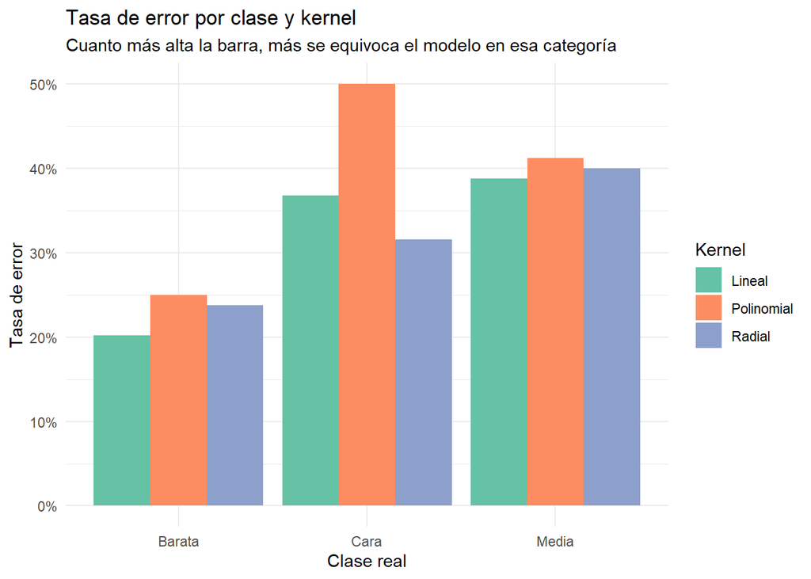

```r
errores %>%
  ggplot(aes(x = Clase, y = Tasa_Error, fill = kernel)) +
  geom_col(position = "dodge") +
  scale_y_continuous(labels = scales::percent_format()) +
  scale_fill_brewer(palette = "Set2") +
  labs(title = "Tasa de error por clase y kernel",
       subtitle = "Cuanto más alta la barra, más se equivoca el modelo en esa categoría",
       x = "Clase real", y = "Tasa de error", fill = "Kernel") +
  theme_minimal()
```